# Data preprocessing for TRIPOD - 10x Genomics PBMC 10k

Yuriko Harigaya, Nancy R. Zhang, Yuchao Jiang

2021-11-19

# 1 Introduction

This is a supplement to [the TRIPOD vignette for the 10x Genomics PBMC data](http://htmlpreview.github.io/?https://github.com/yharigaya/TRIPOD/blob/main/vignettes/TRIPOD_pbmc.html). Here, we demonstrate data preprocessing required for conducting analysis using the TRIPOD package. The input is sigle-cell ATAC/RNA multiomic data, which is publicly available from [10x Genomics](https://support.10xgenomics.com/single-cell-multiome-atac-gex/datasets). The data was generated in 11909 cells of human peripheral blood mononuclear cells (PBMCs) and contains ATAC-seq and RNA-seq read counts for 108377 ATAC peaks and 36601 gene regions, respectively.

# 2 Required packages

The TRIPOD package is available from [GitHub](https://github.com/yharigaya/TRIPOD).

```r
if (!requireNamespace("devtools", quietly = TRUE)) install.packages("devtools")
devtools::install_github("yharigaya/TRIPOD/package")
```

```r
library(TRIPOD)
```

Additionally, the following packages are required to run this vignette.

```r
library(BiocParallel)
library(dplyr)
library(ggplot2)
library(patchwork)
library(Seurat)
library(SeuratDisk)
library(Signac)
library(GenomicRanges)
library(GenomeInfoDb)
library(EnsDb.Hsapiens.v86)
library(BSgenome.Hsapiens.UCSC.hg38)
library(chromVAR)
library(JASPAR2020)
library(TFBSTools)
library(motifmatchr)
```

# 3 Preprocessing

## 3.1 Creating and processing a Seurat object

We first create and process a Seurat object essentially according to the tutorial [here](https://satijalab.org/seurat/articles/weighted_nearest_neighbor_analysis.html). The input data (`pbmc_granulocyte_sorted_10k_filtered_feature_bc_matrix.h5`, `pbmc_granulocyte_sorted_10k_atac_fragments.tsv.gz`, and `pbmc_granulocyte_sorted_10k_atac_fragments.tsv.gz.tbi`) can be downloaded from the 10x Genomics website [here](https://support.10xgenomics.com/single-cell-multiome-atac-gex/datasets).

We obtain cell type labels according to the tutorial [here](https://satijalab.org/seurat/articles/multimodal_reference_mapping.html). The input CITE-seq data (`pbmc_multimodal_citeseq.h5seurat`) can be downloaded [here](https://atlas.fredhutch.org/data/nygc/multimodal/pbmc_multimodal.h5seurat).

In this vignette, we start with a processed Seurat object (`pbmc.chomvar.rds`), which can be downloaded [here](https://www.dropbox.com/s/o2d9kfgdmfsu68a/pbmc.chromvar.rds?dl=0).

## 3.2 Creating objects required for model fitting

From the processed Seurat object, we create a list object containing information that is necessary for model fitting, namely, `transcripts.gr`, `peaks.gr`, `motifxTF`, and `peakxmotif`. See the documentation for more detailed descriptions of these objects.

The following code loads the preprocessed Seurat object.

```r
file <- "pbmc.chomvar.rds"
path <- file.path("path/to/your/dir", file)
pbmc <- readRDS(path); rm(path)
```

We then create a list object containing the four elements required for model fitting (see above). Note the following points.

- We only keep motifs when genes encoding corresponding TFs are present in the RNA-seq data.
- We ensure that the same set of genes is included in all objects.

```r
tripod.pbmc <- getObjectsForModelFit(object = pbmc, chr = paste0("chr", 1:22),
    convert = TRUE)
```

Individual objects can be extracted using the following code.

```r
transcripts.gr <- tripod.pbmc$transcripts.gr
peaks.gr <- tripod.pbmc$peaks.gr
motifxTF <- tripod.pbmc$motifxTF
peakxmotif <- tripod.pbmc$peakxmotif.gr
```

We also filter the Seurat object accordingly.

```r
pbmc <- filterSeuratObject(object = pbmc, tripod.object = tripod.pbmc)
```

We note that our current implementation excludes cases where a TF corresponds to multiple motifs or vice versa. We plan to provide an option to include such degenerate cases in a future version of the package.

## 3.3 Reprocessing of the Seurat object

We then perform normalization, dimension reduction, graph construction, and Uniform Manifold Approximation and Projection (UMAP) embedding for the filtered data using the `processSeuratObject()` function. The function calls several functions from the Seurat packages.

```r
pbmc <- processSeuratObject(object = pbmc, dim.rna = 1:50, dim.atac = 2:50,
    verbose = FALSE)
```

The following code visualizes the data on recalculated graphs.

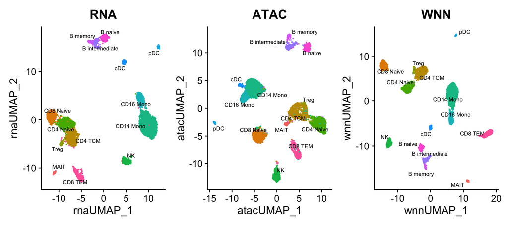

```r
p1 <- DimPlot(pbmc, reduction = "umap.rna",  group.by = "celltype",
    label = TRUE, label.size = 2.5, repel = TRUE) +
    ggtitle("RNA")
p2 <- DimPlot(pbmc, reduction = "umap.atac",  group.by = "celltype",
    label = TRUE, label.size = 2.5, repel = TRUE) +
    ggtitle("ATAC")
p3 <- DimPlot(pbmc, reduction = "wnn.umap", group.by = "celltype",
    label = TRUE, label.size = 2.5, repel = TRUE) +
    ggtitle("WNN")
p1 + p2 + p3 & NoLegend() & theme(plot.title = element_text(hjust = 0.5))
```

## 3.4 Partitioning single cells into metacells

To alleviate the issue of sparsity of the single cell data, we next partition the cells into clusters, which we call metacells. The models in the TRIPOD package are based on metacells, not single cells. Cells can be clustered based on either the ATAC or RNA modality. It is also possible to use the weighted nearest neighbor (WNN) method (Hao et al. 2021). For the PBMC data, we use the WNN method.

To obtain a set of metacells suited for model fitting, it is necessary to select an optimal resolution of clustering to ensure the following.

- a sufficient number of cells per metacell for resolving the sparsity issue
- a sufficient number of metacells to allow for model fitting

Our empirical approach is to select a resolution that gives 80 or more metacells, the majority of which contain 20 or more single cells. For this purpose, we first construct a shared nearest neighbor graph.

Based on the graph calculated in the previous section, we then perform clustering at several resolutions. The following code generates a data frame containing the resolutions, the number of resultant clusters, and the number of clusters with fewer than threshold number of single cells. The threshold is set to 20 cells.

```r
num.clusters <- optimizeResolution(
    object = pbmc,
    graph.name = "wsnn",
    assay.name = "WNN",
    resolutions = seq(10, 35, 5),
    min.num = 20
)
num.clusters
```

```
#>   resolution num_clusters num_below
#> 1         10           61         2
#> 2         15           80         5
#> 3         20          107         6
#> 4         25          138        11
#> 5         30          178        31
#> 6         35          216        62
```

Based on the above analysis, we select the resolution of 15.

```r
res <- 15
pbmc <- getClusters(object = pbmc, graph.name = "wsnn", algorithm = 3,
        resolution = res, verbose = FALSE)
```

We now obtain matrices containing normalized RNA expression and chromatin accessibility per metacell using the `getMetacellMatrices` function. The function returns a list object containing metacell matrices for the RNA and ATAC modalities.

```r
metacell.pbmc <- getMetacellMatrices(object = pbmc,
  cluster.name = "seurat_clusters"
)
```

Individual matrices can be extracted using the following code.

```r
metacell.rna <- metacell.pbmc$rna
metacell.peak <- metacell.pbmc$peak
```

It is necessary to save the Seurat object (`pbmc`) for running [the TRIPOD vignette](http://htmlpreview.github.io/?https://github.com/yharigaya/TRIPOD/blob/main/vignettes/TRIPOD_pbmc.html) since the object is not included in the TRIPOD package.

```r
file <- "pbmc.rds"
path <- file.path("path/to/your/dir", file)
saveRDS(pbmc, path); rm(path)
```

## 3.5 Assigning cell types and colors for visualization

For visualization purposes, it is convenient to assign colors to cell types and create objects storing mapping between them. For this purpose, we use the `getColors()` function, which returns data frames containing mappings of colors to single cells, metacells, and cell types.

```r
color.pbmc <- getColors(object = pbmc)
```

The following code extracts the mapping between the metacells and cell types as a character string. Note that the cell types are ordered by the metacell indices.

```r
metacell.celltype <- color.pbmc$metacell$celltype
metacell.color <- color.pbmc$metacell$color
```

## 3.6 Getting a list of target genes

We typically run model fitting for top-ranked highly variable genes (HVGs) identified by the `VariableFeatures()` function from the Seurat packages. The following code gives a ordered list of top 3000 HVGs.

```r
# obtain highly variable genes based on SCT
DefaultAssay(pbmc) <- "SCT"
hvg.pbmc <- VariableFeatures(pbmc)
```

# References

Hao, Yuhan, Stephanie Hao, Erica Andersen-Nissen, William M. Mauck, Shiwei Zheng, Andrew Butler, Maddie J. Lee, et al. 2021. “Integrated Analysis of Multimodal Single-Cell Data.” *Cell* 184 (June): 3573–3587.e29. https://doi.org/10.1016/j.cell.2021.04.048.